# Carbon Dioxide (CO2) Emission - a Closer Look at EU Countries

# An Analysis of EU Countries

Although carbon dioxide (CO2) makes up the largest share of the greenhouse gases contributing to global warming and climate change, CO2 emissions of a country are only an indicator of one greenhouse gas. For a more complete idea of how a country influences climate change, gases such as methane and nitrous oxide should be taken into account. This is particularly important in agricultural economies.

However, the picture changes dramatically when looking at per capita emissions. The per capita map, distorted by Luxembourg's outlier status, makes it difficult to interpret the true rankings. Using horizontal histograms for a clearer visualization, we can see that the Czech Republic ranks second, with the Netherlands unexpectedly in third place. Moreover, despite being the largest emitter in absolute terms, Germany drops to fifth place when emissions are adjusted for population size.

In summary, while Germany is the undisputed leader in total CO2 emissions, its per capita ranking paints a different picture. This contrast underscores the importance of considering both absolute and per capita figures when analyzing emissions data.

[figure not shown]

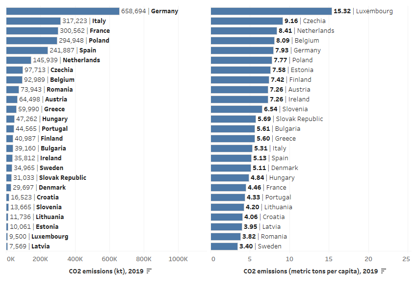

The ranking is clearly different: in absolute numbers Germany is clarly first, it doubles second place Italy two times. Indeed Italy, france, Poand , Spain follow with not a big difference between them. Netherlands is in the six place. However, in per capita measures the picture is a different picture presents itself. Luxembourg is such an olutlier that it obscures the real ranking from the map representation. It is followed by Czech Republic, and interestingly Netherlands as a brozn medal winner. Germany on the other hand is only fifth in this ranking.

So we have frist conclusion, that CO2 emissions in absoluteand per capita numbers exhibit different picture. What about the percentage of different fuel types contibuted in CO2 emissions?

# CO2 Emissions from Different Fuel Types

In recent years, alongside environmental concerns that dominate media discussions on fuel consumption, events such as the 2023 Farmer's protests and the war in Ukraine have highlighted the growing importance of liquid and gaseous fuel consumption in the EU. Let's take a closer look at the CO2 emissions from these two energy sources.

We can easily say that last four years were not really representative of a "standard" situation. So let us look, what were the three main sources of carbon dioxide combustion in the EU in 2019 in particular:

It’s important to recognize that CO2 emissions are not a single entity; they come from various sources. The last four years have been far from a 'normal' situation in terms of emissions, making it useful to look back at 2019 as a more typical year. Let’s explore the three primary sources of carbon dioxide emissions from combustion in the EU in 2019.

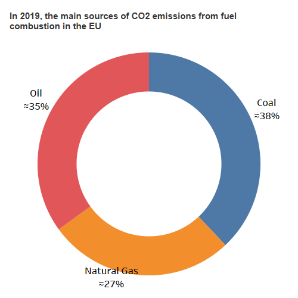

# CO2 Emissions from Liquid and Gaseous Fuel Consumption

The available data on CO2 emissions by fuel type for EU countries is not as comprehensive as other datasets. While the most recent data is from 2016, for France, the latest available data is from 2014. Given that France is one of the largest EU member states, excluding it would make the analysis incomplete. However, transitions between major fuel types in modern economies are typically slow. As demonstrated by the EU's ongoing challenges in reducing natural gas consumption following the war in Ukraine, 2014 can still serve as a reasonably representative year for analysis. Apart from France, if we compare the numbers for other countries there are not significant difference in percentage between 2014 and 2016.

The map below illustrates CO2 emissions from two sources: on the left, CO2 emissions from liquid fuel consumption (in kilotons), primarily reflecting emissions from petroleum-based fuels; and on the right, CO2 emissions from gaseous fuel consumption (in kilotons), mainly representing emissions from natural gas use.

[figure not shown]

A more interesting set of statistics, offering deeper insights, is shown below. This map again highlights CO2 emissions from liquid and gaseous fuel consumption, but this time as a percentage of each country’s total CO2 emissions.

[figure not shown]

Interestingly, Germany does not appear in the top 10 for either liquid or gaseous fuel emissions as a percentage of total emissions. This is notable given that coal remains a major energy source for countries like Germany, Poland, and the Czech Republic. While Germany emits the most CO2 in absolute terms from liquid and gaseous fuels, this data suggests that these fuels are not the primary energy sources for Europe’s largest economy. Instead, coal likely plays a more significant role in Germany’s energy mix.

In other words, CO2 emissions from liquid fuels (such as gasoline and diesel) and gaseous fuels (such as natural gas) vary significantly between countries. These emissions are often linked to transportation and energy production, but their proportion of total emissions can differ greatly depending on the energy mix of each country.

Again, the fact that France, Spain, and Italy appear in both rankings (absolute and percentage) reflects the complexity of their energy consumption patterns. Countries like France may emit a relatively high amount of CO2 from certain fuel types even if their overall emissions are moderated by other sources, such as nuclear power.

# Nexus to Agriculture

The map on the below reflects the EU map with respect to Agriculture, Forestry, and Fishing, Value Added (% of GDP).

[figure not shown]

When examining the intersection between CO2 emissions from liquid and gaseous fuels and the reliance on agriculture, we must consider how the energy needs of agricultural economies differ from those of more industrialized nations. In the EU, countries like Romania, Bulgaria, and Poland—which rank among the top 10 member states with high agricultural dependence—rely heavily on diesel-powered machinery, fertilizers, and irrigation systems. These activities directly influence their consumption of liquid fuels such as diesel, contributing to a unique emissions profile where agriculture plays a significant role. This reliance makes these countries’ emissions from liquid fuels a more notable part of their overall CO2 output, unlike nations where industrial activities dominate the emissions landscape.

Interestingly, countries with large agricultural sectors tend to exhibit a higher percentage of emissions from liquid fuels relative to their total emissions. Romania, for instance, has a significant agricultural sector, which leads to higher fuel consumption in farming equipment and transport. Although these countries may not rank at the top of absolute CO2 emissions, the share of emissions from liquid fuels can be more prominent, reflecting their reliance on agriculture. This differs from countries like Germany and Poland, where coal still plays a large role in the energy mix, causing their CO2 emissions to be driven primarily by fossil fuel combustion for electricity and industry.

While countries like France and Spain rely more heavily on liquid fuels for transportation and industrial activities, agricultural economies contribute significantly to emissions from fertilizers and farm machinery. These differences underline the complexity of emissions in the EU, where the energy needs of agricultural nations shape the ways in which CO2 emissions from various fuel types manifest.

# Detailed Description of Variables and References

## Descriptions of the variables:

**GDP (constant 2015 US$)** - GDP at purchaser's prices is the sum of gross value added by all resident producers in the economy plus any product taxes and minus any subsidies not included in the value of the products. It is calculated without making deductions for depreciation of fabricated assets or for depletion and degradation of natural resources. Data are in constant 2015 prices, expressed in U.S. dollars. Dollar figures for GDP are converted from domestic currencies using 2015 official exchange rates. For a few countries where the official exchange rate does not reflect the rate effectively applied to actual foreign exchange transactions, an alternative conversion factor is used.

**Agriculture, forestry, and fishing, value added (% of GDP)** - Agriculture, forestry, and fishing corresponds to ISIC divisions 1-3 and includes forestry, hunting, and fishing, as well as cultivation of crops and livestock production. Value added is the net output of a sector after adding up all outputs and subtracting intermediate inputs. It is calculated without making deductions for depreciation of fabricated assets or depletion and degradation of natural resources. The origin of value added is determined by the International Standard Industrial Classification (ISIC), revision 4. Note: For VAB countries, gross value added at factor cost is used as the denominator.

## Sources used for this analysis:

[Ember Climate](https://ember-climate.org/insights/research/eu-ets-2022/)

[World Bank Open Data](https://data.worldbank.org/)

[EuroStat](https://ec.europa.eu/eurostat)